# Data Visualization

## *Data Visualization*

is one of the most important aspects in data analysis as it offers deeper insights into the data.

Bad Visualizations can be misleading which results in poor analysis

### Bad Visualization

[figure not shown]

## =========================================

## The Four Levels of Measurement

In order to choose an appropriate plot type or method of analysis for your data, you need to understand the types of data you have. One common method divides the data into four levels of measurement:

### Qualitative or categorical types (non-numeric types)

1. Nominal data: pure labels without inherent order (no label is intrinsically greater or less than any other)
2. Ordinal data: labels with an intrinsic order or ranking (comparison operations can be made between values, but the magnitude of differences are not be well-defined) ### Quantitative or numeric types
3. Interval data: numeric values where absolute differences are meaningful (addition and subtraction operations can be made)
4. Ratio data: numeric values where relative differences are meaningful (multiplication and division operations can be made) All quantitative-type variables also come in one of two varieties: discrete and continuous.

Discrete quantitative variables can only take on a specific set values at some maximum level of precision. Continuous quantitative variables can (hypothetically) take on values to any level of precision.  
Distinguishing between continuous and discrete can be a little tricky – a rule of thumb is if there are few levels, and values can't be subdivided into further units, then it's discrete.Otherwise, it's continuous. If you have a scale that can only take natural number values between 1 and 5, that's discrete. A quantity that can be measured to two digits, e.g. 2.72, is best characterized as continuous, since we might hypothetically be able to measure to even more digits, e.g. 2.718. A tricky case like test scores measured between 0 and 100 can only be divided down to single integers, making it initially seem discrete. But since there are so many values, such a feature is usually considered as continuous.  
When exploring your data, the most important thing to consider first is whether your data is qualitative or quantitative. In later lessons, you will see how this distinction impacts your choice of plots.

## Univariate Plots

*Univaraite Plots* are used to plot a single column of the dataset

### Types of for univariate data:

For qualitative variables, we use bar charts  
For quantitative variables, we use histograms

[figure not shown]

### Try to identify the issue with that plot

[figure not shown]

### ==============================================

## Data order is important for ordinal data

[figure not shown]

```python
# Necessary imports
import numpy as np
import pandas as pd
import matplotlib.pyplot as plt
import seaborn as sb
%matplotlib inline
```

```python
# Read the csv file, and check its top 10 rows
pokemon = pd.read_csv('pokemon.csv')
print(pokemon.shape)
pokemon.head(10)
```

[output not shown]

```python
# df=pokemon[["height",'weight',"base_experience","hp","attack","defense","speed","special-attack","special-defense"]]
print(pokemon.head())
pokemon['generation_id'].value_counts()
```

```
   id     species  generation_id  height  weight  base_experience type_1
0   1   bulbasaur              1     0.7     6.9               64  grass  \
1   2     ivysaur              1     1.0    13.0              142  grass
2   3    venusaur              1     2.0   100.0              236  grass
3   4  charmander              1     0.6     8.5               62   fire
4   5  charmeleon              1     1.1    19.0              142   fire

   type_2  hp  attack  defense  speed  special-attack  special-defense
0  poison  45      49       49     45              65               65
1  poison  60      62       63     60              80               80
2  poison  80      82       83     80             100              100
3     NaN  39      52       43     65              60               50
4     NaN  58      64       58     80              80               65
```

```
generation_id
5    156
1    151
3    135
4    107
2    100
7     86
6     72
Name: count, dtype: int64
```

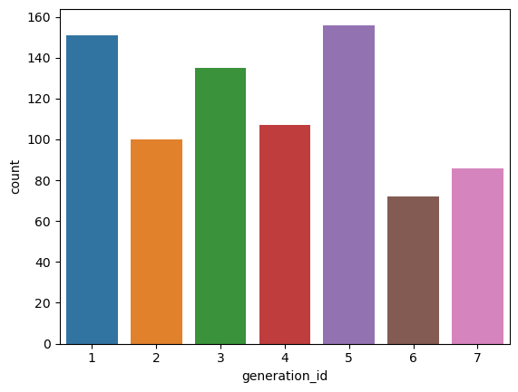

```python
# A semicolon (;) at the end of the statement will supress printing the plotting information
sb.countplot(data=pokemon, x='generation_id');
```

In the example above, all the bars have a different color. This might come in handy for building associations between these category labels and encodings in plots with more variables. Otherwise, it's a good idea to simplify the plot and reduce unnecessary distractions by plotting all bars in the same color. You can choose to have a uniform color across all bars, by using the `color` argument, as shown in the example below:

```python
# The `color_palette()` returns the the current / default palette as a list of RGB tuples.
# Each tuple consists of three digits specifying the red, green, and blue channel values to specify a color.
# Choose the first tuple of RGB colors
sb.color_palette()
```

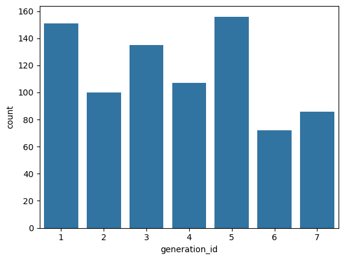

```python
base_color = sb.color_palette()[0]

# Use the `color` argument
sb.countplot(data=pokemon, x='generation_id', color=base_color);
```

## Bar Chart using the Matplotlib

You can even create a similar bar chart using the Matplotlib, instead of Seaborn. We will use the `matplotlib.pyplot.bar()`(opens in a new tab) function to plot the chart. The syntax is:  
`matplotlib.pyplot.bar(x, y, width=0.8, bottom=None, *, align='center', data=None)`

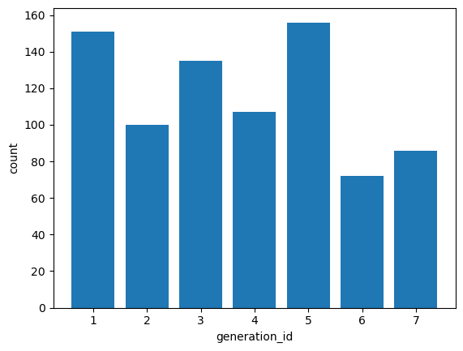

```python
# Return the Series having unique values
x = pokemon['generation_id'].unique()

# Return the Series having frequency count of each unique value
y = pokemon['generation_id'].value_counts(sort=False)

plt.bar(x, y)

# Labeling the axes
plt.xlabel('generation_id')
plt.ylabel('count')

# Dsiplay the plot
plt.show()
```

There is a lot more you can do with both Seaborn and Matplotlib bar charts. The remaining examples will experiment with seaborn's `countplot()` function.  
For nominal-type data, one common operation is to sort the data in terms of frequency. In the examples shown above, you can even order the bars as desirable. With our data in a pandas DataFrame, we can use various DataFrame methods to compute and extract an ordering, then set that ordering on the "order" parameter:

This can be done by using the `order` argument of the `countplot()` function.

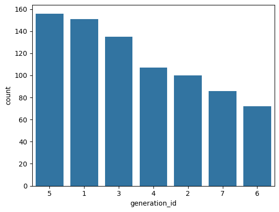

```python
# Static-ordering the bars
sb.countplot(data=pokemon, x='generation_id', color=base_color, order=[5,1,3,4,2,7,6]);

# Dynamic-ordering the bars
# The order of the display of the bars can be computed with the following logic.
# Count the frequency of each unique value in the 'generation_id' column, and sort it in descending order
# Returns a Series
freq = pokemon['generation_id'].value_counts()

# Get the indexes of the Series
gen_order = freq.index

# Plot the bar chart in the decreasing order of the frequency of the `generation_id`
sb.countplot(data=pokemon, x='generation_id', color=base_color, order=gen_order);
```

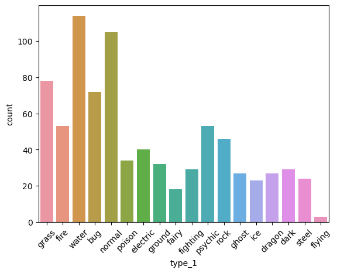

```python
# Plot the Pokemon type on a Vertical bar chart
sb.countplot(data=pokemon, x='type_1',);

# Use xticks to rotate the category labels (not axes) counter-clockwise
plt.xticks(rotation=45);
```

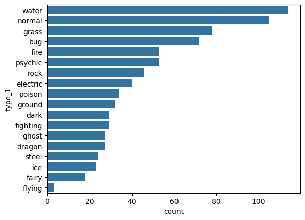

```python
# Plot the Pokemon type on a Horizontal bar chart
type_order = pokemon['type_1'].value_counts().index
sb.countplot(data=pokemon, y='type_1', color=base_color, order=type_order);
```

# Absolute and relative frequency

By default, seaborn's `countplot` function will summarize and plot the data in terms of absolute frequency, or pure counts. In certain cases, you might want to understand the distribution of data or want to compare levels in terms of the proportions of the whole. In this case, you will want to plot the data in terms of relative frequency, where the height indicates the proportion of data taking each level, rather than the absolute count.

One method of plotting the data in terms of relative frequency on a bar chart is to just relabel the count's axis in terms of proportions. The underlying data will be the same, it will simply be the scale of the axis ticks that will be changed.

```python
pokemon.head()
```

|  | id | species | generation_id | height | weight | base_experience | type_1 | type_2 | hp | attack | defense | speed | special-attack | special-defense |
| --- | --- | --- | --- | --- | --- | --- | --- | --- | --- | --- | --- | --- | --- | --- |
| 0 | 1 | bulbasaur | 1 | 0.7 | 6.9 | 64 | grass | poison | 45 | 49 | 49 | 45 | 65 | 65 |
| 1 | 2 | ivysaur | 1 | 1.0 | 13.0 | 142 | grass | poison | 60 | 62 | 63 | 60 | 80 | 80 |
| 2 | 3 | venusaur | 1 | 2.0 | 100.0 | 236 | grass | poison | 80 | 82 | 83 | 80 | 100 | 100 |
| 3 | 4 | charmander | 1 | 0.6 | 8.5 | 62 | fire | NaN | 39 | 52 | 43 | 65 | 60 | 50 |
| 4 | 5 | charmeleon | 1 | 1.1 | 19.0 | 142 | fire | NaN | 58 | 64 | 58 | 80 | 80 | 65 |

```python
pkmn_types = pokemon.melt(['id', 'species'],
                          value_vars=['type_1', 'type_2'],
                          var_name='type_level',
                          value_name='type')
```

```python
t=pkmn_types.sort_values('species')
```

```python
t.head()
```

|  | id | species | type_level | type |
| --- | --- | --- | --- | --- |
| 1266 | 460 | abomasnow | type_2 | ice |
| 459 | 460 | abomasnow | type_1 | grass |
| 62 | 63 | abra | type_1 | psychic |
| 869 | 63 | abra | type_2 | NaN |
| 358 | 359 | absol | type_1 | dark |

```python
type_counts = pkmn_types['type'].value_counts()
type_counts
```

```
type
water       131
normal      109
flying       98
grass        97
psychic      82
bug          77
poison       66
ground       64
fire         64
rock         60
fighting     54
electric     48
fairy        47
steel        47
dark         46
dragon       45
ghost        43
ice          34
Name: count, dtype: int64
```

```python
type_order = type_counts.index
type_order
```

```
Index(['water', 'normal', 'flying', 'grass', 'psychic', 'bug', 'poison',
       'ground', 'fire', 'rock', 'fighting', 'electric', 'fairy', 'steel',
       'dark', 'dragon', 'ghost', 'ice'],
      dtype='object', name='type')
```

## Plotting the horizontal bars

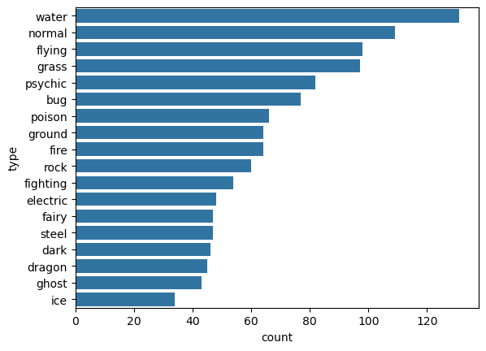

```python
base_color = sb.color_palette()[0]
sb.countplot(data=pkmn_types, y='type', color=base_color, order=type_order);
```

### 1. Plot a bar chart having the proportions, instead of the actual count, on one of the axes.

Step 1. Find the maximum proportion of bar

```python
# Returns the sum of all not-null values in `type` column
n_pokemon = pkmn_types['type'].value_counts().sum()

# Return the highest frequency in the `type` column
max_type_count = type_counts[0]

# Return the maximum proportion, or in other words,
# compute the length of the longest bar in terms of the proportion
max_prop = max_type_count / n_pokemon
print(max_prop)
```

```
0.10808580858085809
```

```python
n_pokemon
```

```
1212
```

Step 2. Create an array of evenly spaced proportioned values

```python
# Use numpy.arange() function to produce a set of evenly spaced proportioned values
# between 0 and max_prop, with a step size 2\%
tick_props = np.arange(0, max_prop, 0.02)
tick_props
```

```
array([0.  , 0.02, 0.04, 0.06, 0.08, 0.1 ])
```

We need x-tick labels that must be evenly spaced on the x-axis. For this purpose, we must have a list of labels ready with us, before using it with `plt.xticks()` function.

```python
# Use a list comprehension to create tick_names that we will apply to the tick labels.
# Pick each element `v` from the `tick_props`, and convert it into a formatted string.
# `{:0.2f}` denotes that before formatting, we 2 digits of precision and `f` is used to represent floating point number.
# Refer [here](https://docs.python.org/2/library/string.html#format-string-syntax) for more details
tick_names = ['{:0.2f}'.format(v) for v in tick_props]
tick_names
```

```
['0.00', '0.02', '0.04', '0.06', '0.08', '0.10']
```

The `xticks`and `yticks` functions aren't only about rotating the tick labels. You can also get and set their locations and labels as well. The first argument takes the tick locations: in this case, the tick proportions multiplied back to be on the scale of counts. The second argument takes the tick names: in this case, the tick proportions formatted as strings to two decimal places.

### Step 4. Plot the bar chart, with new x-tick labels

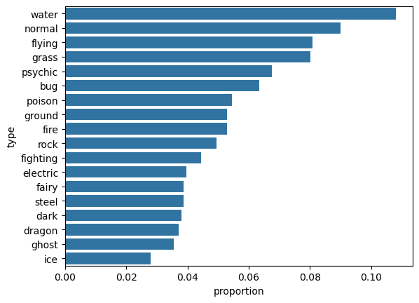

```python
sb.countplot(data=pkmn_types, y='type', color=base_color, order=type_order);
# Change the tick locations and labels
plt.xticks(tick_props * n_pokemon, tick_names)
plt.xlabel('proportion');
```

## Print the text (proportion) on the bars of a horizontal plot.

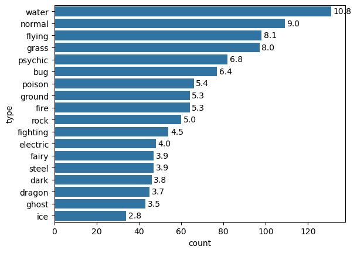

```python
# Considering the same chart from the Example 1 above, print the text (proportion) on the bars
base_color = sb.color_palette()[0]
sb.countplot(data=pkmn_types, y='type', color=base_color, order=type_order);

# Logic to print the proportion text on the bars
for i in range (type_counts.shape[0]):
    # Remember, type_counts contains the frequency of unique values in the `type` column in decreasing order.
    count = type_counts[i]
    # Convert count into a percentage, and then into string
    pct_string = '{:0.1f}'.format(100*count/n_pokemon)
    # Print the string value on the bar.
    # Read more about the arguments of text() function [here](https://matplotlib.org/3.1.1/api/_as_gen/matplotlib.pyplot.text.html)
    plt.text(count+1, i, pct_string, va='center')
```

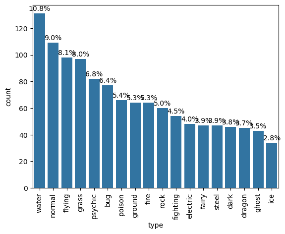

```python
# Considering the same chart from the Example 1 above, print the text (proportion) BELOW the bars
base_color = sb.color_palette()[0]
sb.countplot(data=pkmn_types, x='type', color=base_color, order=type_order);


# Recalculating the type_counts just to have clarity.
type_counts = pkmn_types['type'].value_counts()

# get the current tick locations and labels
locs, labels = plt.xticks(rotation=90)

# loop through each pair of locations and labels
for loc, label in zip(locs, labels):

    # get the text property for the label to get the correct count
    count = type_counts[label.get_text()]
    pct_string = '{:0.1f}%'.format(100*count/n_pokemon)

    # print the annotation just below the top of the bar
    plt.text(loc, count+2, pct_string, ha = 'center', color = 'black')
```

```python
from matplotlib import rcParams
# Specify the figure size in inches, for both X, and Y axes
rcParams['figure.figsize'] = 12,4
```

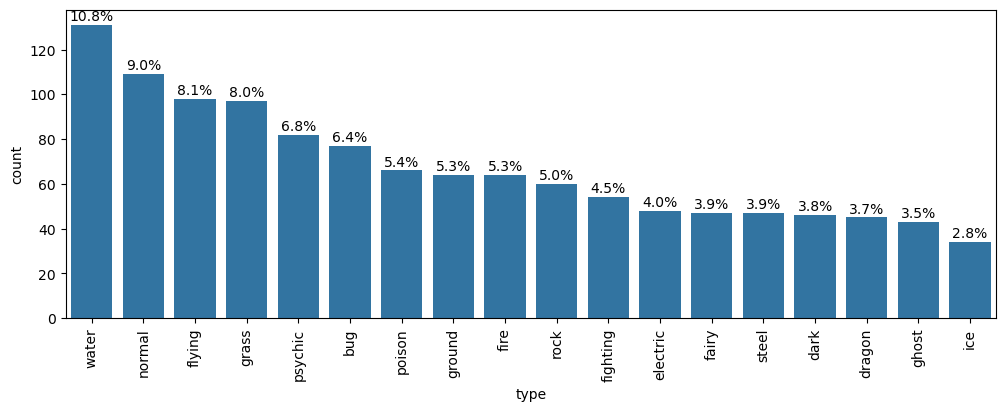

```python
# Considering the same chart from the Example 1 above, print the text (proportion) BELOW the bars
base_color = sb.color_palette()[0]
sb.countplot(data=pkmn_types, x='type', color=base_color, order=type_order);


# Recalculating the type_counts just to have clarity.
type_counts = pkmn_types['type'].value_counts()

# get the current tick locations and labels
locs, labels = plt.xticks(rotation=90)

# loop through each pair of locations and labels
for loc, label in zip(locs, labels):

    # get the text property for the label to get the correct count
    count = type_counts[label.get_text()]
    pct_string = '{:0.1f}%'.format(100*count/n_pokemon)

    # print the annotation just below the top of the bar
    plt.text(loc, count+2, pct_string, ha = 'center', color = 'black')
```

## Pie Charts

A pie chart is a common univariate plot type that is used to depict relative frequencies for levels of a categorical variable. Frequencies in a pie chart are depicted as wedges drawn on a circle: the larger the angle or area, the more common the categorical value taken. Use a Pie chart only when the number of categories is less, and you'd like to see the proportion of each category on a chart.

[figure not shown]

Unfortunately, pie charts are a fairly limited plot type in the range of scenarios where they can be used, and it is easy for chart makers to try and spice up pie charts in a way that makes them more difficult to read.

### Guidelines to Use a Pie Chart

If you want to use a pie chart, try to follow certain guidelines:

Make sure that your interest is in relative frequencies. Areas should represent parts of a whole, rather than measurements on a second variable (unless that second variable can logically be summed up into some whole).  
Limit the number of slices plotted. A pie chart works best with two or three slices, though it's also possible to plot with four or five slices as long as the wedge sizes can be distinguished. If you have a lot of categories, or categories that have small proportional representation, consider grouping them together so that fewer wedges are plotted, or use an 'Other' category to handle them.  
>  
Plot the data systematically. One typical method of plotting a pie chart is to start from the top of the circle, then plot each categorical level clockwise from most frequent to least frequent. If you have three categories and are interested in the comparison of two of them, a common plotting method is to place the two categories of interest on either side of the 12 o'clock direction, with the third category filling in the remaining space at the bottom.

If these guidelines cannot be met, then you should probably make use of a bar chart instead. A bar chart is a safer choice in general. The bar heights are more precisely interpreted than areas or angles, and a bar chart can be displayed more compactly than a pie chart. There's also more flexibility with a bar chart for plotting variables with a lot of levels, like plotting the bars horizontally.

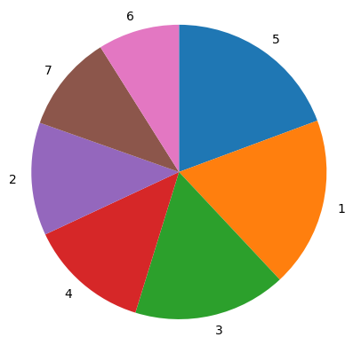

```python
# Use the same pokemon dataset
sorted_counts = pokemon['generation_id'].value_counts()

plt.pie(sorted_counts, labels = sorted_counts.index, startangle = 90, counterclock = False);

# We have the used option `Square`.
# Though, you can use either one specified here - https://matplotlib.org/api/_as_gen/matplotlib.pyplot.axis.html?highlight=pyplot%20axis#matplotlib-pyplot-axis
plt.axis('square');
```

```python
sorted_counts.index
```

```
Index([5, 1, 3, 4, 2, 7, 6], dtype='int64', name='generation_id')
```

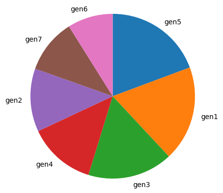

```python
# Use the same pokemon dataset
sorted_counts = pokemon['generation_id'].value_counts()

plt.pie(sorted_counts, labels = ['gen5', 'gen1', 'gen3', 'gen4', 'gen2', 'gen7', 'gen6'], startangle = 90, counterclock = False);

# We have the used option `Square`.
# Though, you can use either one specified here - https://matplotlib.org/api/_as_gen/matplotlib.pyplot.axis.html?highlight=pyplot%20axis#matplotlib-pyplot-axis
plt.axis('square');
```

# Histograms

A histogram is used to plot the distribution of a numeric variable. It's the quantitative version of the bar chart. However, rather than plot one bar for each unique numeric value, values are grouped into continuous bins, and one bar for each bin is plotted to depict the number. You can use either Matplotlib or Seaborn to plot the histograms. There is a mild variation in the specifics, such as plotting gaussian-estimation line along with bars in Seabron's distplot(), and the arguments that you can use in either case.

[figure not shown]

Histograms can provide views on data distribution

[figure not shown]

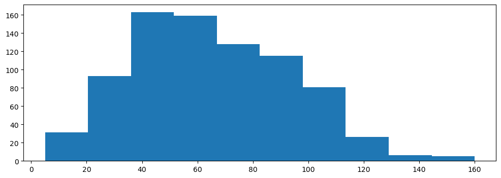

```python
# We have intentionally not put a semicolon at the end of the statement below to see the bar-width
plt.hist(data = pokemon, x = 'speed')
```

There is a non-uniform distribution of data points in different bins.

By default, the `hist` function divides the data into 10 bins, based on the range of values taken. In almost every case, we will want to change these settings. Usually, having only ten bins is too few to really understand the distribution of the data. And the default tick marks are often not on nice, 'round' values that make the ranges taken by each bin easy to interpret.

You can use descriptive statistics (e.g. via dataframe['column'].describe()(opens in a new tab)) to gauge what minimum and maximum bin limits might be appropriate for the plot. These bin edges can be set using numpy's arange(opens in a new tab) function:

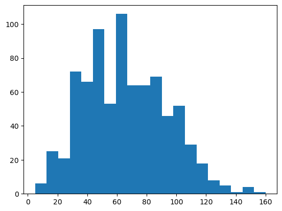

```python
# fixed number of bins
plt.hist(data = pokemon, x = 'speed', bins = 20);
# plt.xlabel('speed')
```

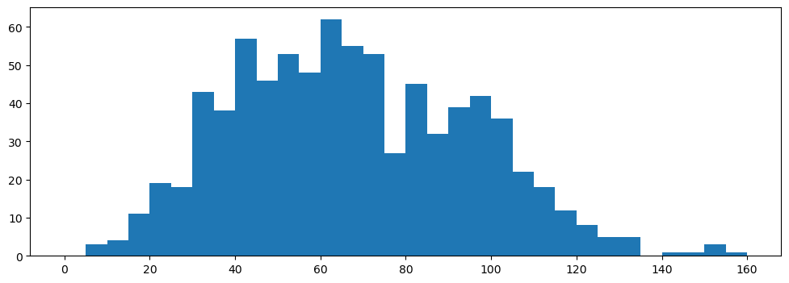

```python
# Dynamic number of bins
# Create bins with step-size 5
bins = np.arange(0, pokemon['speed'].max()+5, 5)
plt.hist(data = pokemon, x = 'speed', bins = bins)
```

# Bivariate Plots

to visualize the relationships between two variables

[figure not shown]

## Scatterplots

If we want to inspect the relationship between two numeric variables, the standard choice of plot is the scatterplot. In a scatterplot, each data point is plotted individually as a point, its x-position corresponding to one feature value and its y-position corresponding to the second.

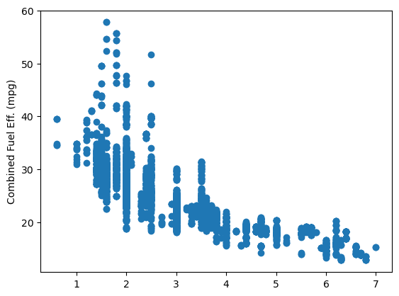

```python
# Read the CSV file
fuel_econ = pd.read_csv('fuel-econ.csv')
# fuel_econ.head(10)

# Scatter plot
plt.scatter(data = fuel_econ, x = 'displ', y = 'comb');
# plt.xlabel('Displacement (1)')
plt.ylabel('Combined Fuel Eff. (mpg)')
```

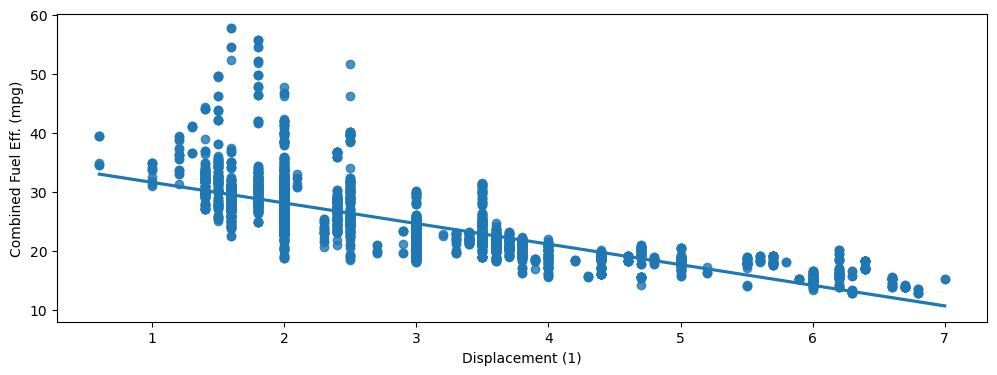

```python
# negative relationship
sb.regplot(data = fuel_econ, x = 'displ', y = 'comb');
plt.xlabel('Displacement (1)')
plt.ylabel('Combined Fuel Eff. (mpg)')
```

## Heat Maps

A heat map is a 2-d version of the histogram that can be used as an alternative to a scatterplot. Like a scatterplot, the values of the two numeric variables to be plotted are placed on the plot axes. Similar to a histogram, the plotting area is divided into a grid and the number of points in each grid rectangle is added up. Since there won't be room for bar heights, counts are indicated instead by grid cell color. A heat map can be implemented with Matplotlib's `hist2d()` function.

```python
fuel_econ.head()
```

|  | id | make | model | year | VClass | drive | trans | fuelType | cylinders | displ | pv2 | pv4 | city | UCity | highway | UHighway | comb | co2 | feScore | ghgScore |
| --- | --- | --- | --- | --- | --- | --- | --- | --- | --- | --- | --- | --- | --- | --- | --- | --- | --- | --- | --- | --- |
| 0 | 32204 | Nissan | GT-R | 2013 | Subcompact Cars | All-Wheel Drive | Automatic (AM6) | Premium Gasoline | 6 | 3.8 | 79 | 0 | 16.4596 | 20.2988 | 22.5568 | 30.1798 | 18.7389 | 471 | 4 | 4 |
| 1 | 32205 | Volkswagen | CC | 2013 | Compact Cars | Front-Wheel Drive | Automatic (AM-S6) | Premium Gasoline | 4 | 2.0 | 94 | 0 | 21.8706 | 26.9770 | 31.0367 | 42.4936 | 25.2227 | 349 | 6 | 6 |
| 2 | 32206 | Volkswagen | CC | 2013 | Compact Cars | Front-Wheel Drive | Automatic (S6) | Premium Gasoline | 6 | 3.6 | 94 | 0 | 17.4935 | 21.2000 | 26.5716 | 35.1000 | 20.6716 | 429 | 5 | 5 |
| 3 | 32207 | Volkswagen | CC 4motion | 2013 | Compact Cars | All-Wheel Drive | Automatic (S6) | Premium Gasoline | 6 | 3.6 | 94 | 0 | 16.9415 | 20.5000 | 25.2190 | 33.5000 | 19.8774 | 446 | 5 | 5 |
| 4 | 32208 | Chevrolet | Malibu eAssist | 2013 | Midsize Cars | Front-Wheel Drive | Automatic (S6) | Regular Gasoline | 4 | 2.4 | 0 | 95 | 24.7726 | 31.9796 | 35.5340 | 51.8816 | 28.6813 | 310 | 8 | 8 |

```python
df=fuel_econ[['cylinders', 'displ', 'pv2', 'pv4', 'city', 'UCity', 'highway',
       'UHighway', 'comb', 'co2', 'feScore', 'ghgScore']]

df.corr()
```

|  | cylinders | displ | pv2 | pv4 | city | UCity | highway | UHighway | comb | co2 | feScore | ghgScore |
| --- | --- | --- | --- | --- | --- | --- | --- | --- | --- | --- | --- | --- |
| cylinders | 1.000000 | 0.933872 | 0.247571 | -0.004264 | -0.693103 | -0.666029 | -0.766275 | -0.771503 | -0.738023 | 0.848274 | -0.783858 | -0.781815 |
| displ | 0.933872 | 1.000000 | 0.259336 | 0.022072 | -0.713479 | -0.686166 | -0.783984 | -0.788457 | -0.758397 | 0.855375 | -0.793432 | -0.791216 |
| pv2 | 0.247571 | 0.259336 | 1.000000 | -0.665642 | -0.278109 | -0.272546 | -0.296808 | -0.298504 | -0.290883 | 0.287200 | -0.296088 | -0.293156 |
| pv4 | -0.004264 | 0.022072 | -0.665642 | 1.000000 | 0.035188 | 0.037869 | 0.074952 | 0.077442 | 0.047333 | -0.050153 | 0.064876 | 0.065263 |
| city | -0.693103 | -0.713479 | -0.278109 | 0.035188 | 1.000000 | 0.996377 | 0.915435 | 0.909658 | 0.989552 | -0.904305 | 0.905681 | 0.898793 |
| UCity | -0.666029 | -0.686166 | -0.272546 | 0.037869 | 0.996377 | 1.000000 | 0.899557 | 0.897814 | 0.981106 | -0.885823 | 0.891297 | 0.884458 |
| highway | -0.766275 | -0.783984 | -0.296808 | 0.074952 | 0.915435 | 0.899557 | 1.000000 | 0.992191 | 0.962757 | -0.916456 | 0.914116 | 0.897585 |
| UHighway | -0.771503 | -0.788457 | -0.298504 | 0.077442 | 0.909658 | 0.897814 | 0.992191 | 1.000000 | 0.956580 | -0.912117 | 0.911355 | 0.894314 |
| comb | -0.738023 | -0.758397 | -0.290883 | 0.047333 | 0.989552 | 0.981106 | 0.962757 | 0.956580 | 1.000000 | -0.929399 | 0.928862 | 0.918807 |
| co2 | 0.848274 | 0.855375 | 0.287200 | -0.050153 | -0.904305 | -0.885823 | -0.916456 | -0.912117 | -0.929399 | 1.000000 | -0.940624 | -0.944566 |
| feScore | -0.783858 | -0.793432 | -0.296088 | 0.064876 | 0.905681 | 0.891297 | 0.914116 | 0.911355 | 0.928862 | -0.940624 | 1.000000 | 0.994231 |
| ghgScore | -0.781815 | -0.791216 | -0.293156 | 0.065263 | 0.898793 | 0.884458 | 0.897585 | 0.894314 | 0.918807 | -0.944566 | 0.994231 | 1.000000 |

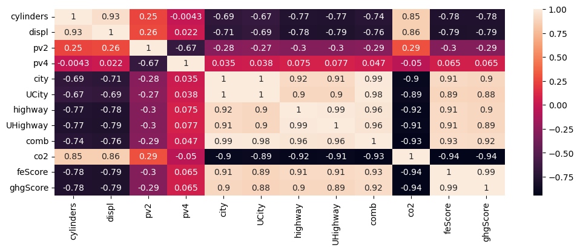

```python
sb.heatmap(df.corr(),annot=True)
```

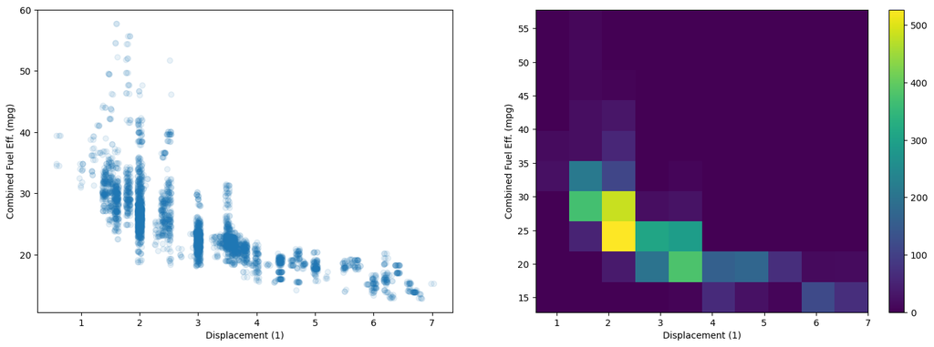

```python
plt.figure(figsize = [18, 6])

# PLOT ON LEFT
plt.subplot(1, 2, 1)
sb.regplot(data = fuel_econ, x = 'displ', y = 'comb', x_jitter=0.04, scatter_kws={'alpha':1/10}, fit_reg=False)
plt.xlabel('Displacement (1)')
plt.ylabel('Combined Fuel Eff. (mpg)');

# PLOT ON RIGHT
plt.subplot(1, 2, 2)
plt.hist2d(data = fuel_econ, x = 'displ', y = 'comb')
plt.colorbar()
plt.xlabel('Displacement (1)')
plt.ylabel('Combined Fuel Eff. (mpg)');
```

## Violin Plots

There are a few ways of plotting the relationship between one quantitative and one qualitative variable, that demonstrate the data at different levels of abstraction. The violin plot is on the lower level of abstraction. For each level of the categorical variable, a distribution of the values on the numeric variable is plotted. The distribution is plotted as a kernel density estimate, something like a smoothed histogram. There is an extra section at the end of the previous lesson that provides more insight into kernel density estimates.

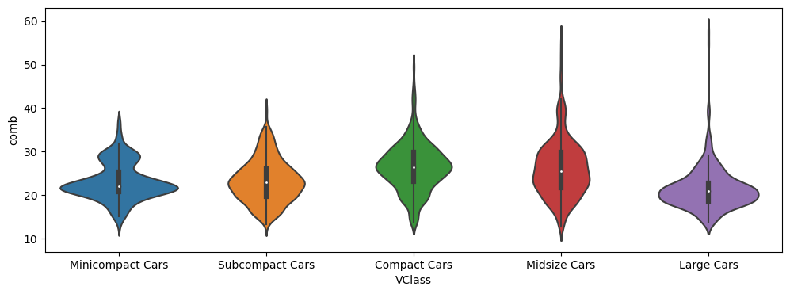

```python
# Violin plot for plotting a Quantitative variable (fuel efficiency) versus Qualitative variable (vehicle class)
# Types of sedan cars
sedan_classes = ['Minicompact Cars', 'Subcompact Cars', 'Compact Cars', 'Midsize Cars', 'Large Cars']

# Returns the types for sedan_classes with the categories and orderedness
# Refer - https://pandas.pydata.org/pandas-docs/version/0.23.4/generated/pandas.api.types.CategoricalDtype.html
vclasses = pd.api.types.CategoricalDtype(ordered=True, categories=sedan_classes)

# Use pandas.astype() to convert the "VClass" column from a plain object type into an ordered categorical type
fuel_econ['VClass'] = fuel_econ['VClass'].astype(vclasses);

sb.violinplot(data=fuel_econ, x='VClass', y='comb');
```

## Box Plots

A box plot is another way of showing the relationship between a numeric variable and a categorical variable. Compared to the violin plot, the box plot leans more on the summarization of the data, primarily just reporting a set of descriptive statistics for the numeric values on each categorical level. A box plot can be created using seaborn's boxplot()(opens in a new tab) function.

```
(6.966470319355814, 63.09321945242605)
```

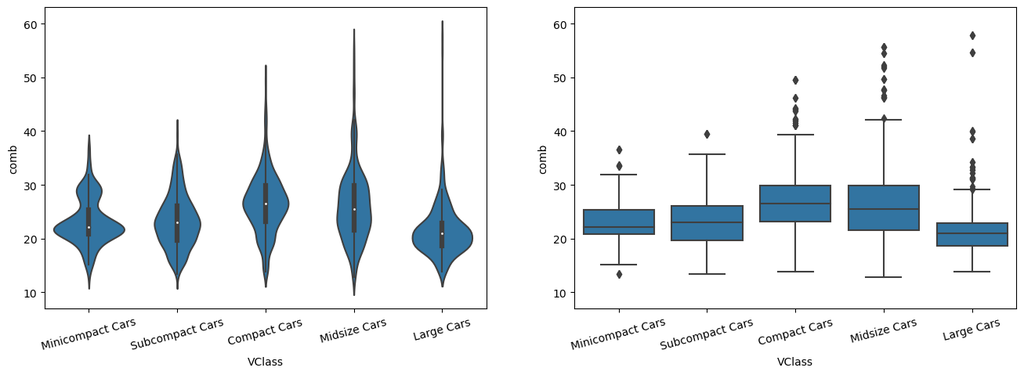

```python
# Step 3. Convert the "VClass" column from a plain object type into an ordered categorical type
# Types of sedan cars
sedan_classes = ['Minicompact Cars', 'Subcompact Cars', 'Compact Cars', 'Midsize Cars', 'Large Cars']

# Returns the types for sedan_classes with the categories and orderedness
# Refer - https://pandas.pydata.org/pandas-docs/version/0.23.4/generated/pandas.api.types.CategoricalDtype.html
vclasses = pd.api.types.CategoricalDtype(ordered=True, categories=sedan_classes)

# Use pandas.astype() to convert the "VClass" column from a plain object type into an ordered categorical type
fuel_econ['VClass'] = fuel_econ['VClass'].astype(vclasses);

# Step 4.  TWO PLOTS IN ONE FIGURE
plt.figure(figsize = [16, 5])
base_color = sb.color_palette()[0]

# LEFT plot: violin plot
plt.subplot(1, 2, 1)
#Let's return the axes object
ax1 = sb.violinplot(data=fuel_econ, x='VClass', y='comb', color=base_color, innner='quartile')
plt.xticks(rotation=15);

# RIGHT plot: box plot
plt.subplot(1, 2, 2)
sb.boxplot(data=fuel_econ, x='VClass', y='comb', color=base_color)
plt.xticks(rotation=15);
plt.ylim(ax1.get_ylim()) # set y-axis limits to be same as left plot
```

```python
fuel_econ.head()
```

|  | id | make | model | year | VClass | drive | trans | fuelType | cylinders | displ | pv2 | pv4 | city | UCity | highway | UHighway | comb | co2 | feScore | ghgScore |
| --- | --- | --- | --- | --- | --- | --- | --- | --- | --- | --- | --- | --- | --- | --- | --- | --- | --- | --- | --- | --- |
| 0 | 32204 | Nissan | GT-R | 2013 | Subcompact Cars | All-Wheel Drive | Automatic (AM6) | Premium Gasoline | 6 | 3.8 | 79 | 0 | 16.4596 | 20.2988 | 22.5568 | 30.1798 | 18.7389 | 471 | 4 | 4 |
| 1 | 32205 | Volkswagen | CC | 2013 | Compact Cars | Front-Wheel Drive | Automatic (AM-S6) | Premium Gasoline | 4 | 2.0 | 94 | 0 | 21.8706 | 26.9770 | 31.0367 | 42.4936 | 25.2227 | 349 | 6 | 6 |
| 2 | 32206 | Volkswagen | CC | 2013 | Compact Cars | Front-Wheel Drive | Automatic (S6) | Premium Gasoline | 6 | 3.6 | 94 | 0 | 17.4935 | 21.2000 | 26.5716 | 35.1000 | 20.6716 | 429 | 5 | 5 |
| 3 | 32207 | Volkswagen | CC 4motion | 2013 | Compact Cars | All-Wheel Drive | Automatic (S6) | Premium Gasoline | 6 | 3.6 | 94 | 0 | 16.9415 | 20.5000 | 25.2190 | 33.5000 | 19.8774 | 446 | 5 | 5 |
| 4 | 32208 | Chevrolet | Malibu eAssist | 2013 | Midsize Cars | Front-Wheel Drive | Automatic (S6) | Regular Gasoline | 4 | 2.4 | 0 | 95 | 24.7726 | 31.9796 | 35.5340 | 51.8816 | 28.6813 | 310 | 8 | 8 |

## Clustered Bar Charts

To depict the relationship between two categorical variables, we can extend the univariate bar chart seen in the previous lesson into a clustered bar chart. Like a standard bar chart, we still want to depict the count of data points in each group, but each group is now a combination of labels on two variables. So we want to organize the bars into an order that makes the plot easy to interpret. In a clustered bar chart, bars are organized into clusters based on levels of the first variable, and then bars are ordered consistently across the second variable within each cluster. This is easiest to see with an example, using seaborn's countplot(opens in a new tab) function. To take the plot from univariate to bivariate, we add the second variable to be plotted under the "hue" argument:

```python
# Plot a Bar chart between two qualitative variables
# Preparatory Step 1 - Convert the "VClass" column from a plain object type into an ordered categorical type
# Types of sedan cars
sedan_classes = ['Minicompact Cars', 'Subcompact Cars', 'Compact Cars', 'Midsize Cars', 'Large Cars']

# Returns the types for sedan_classes with the categories and orderedness
# Refer - https://pandas.pydata.org/pandas-docs/version/0.23.4/generated/pandas.api.types.CategoricalDtype.html
vclasses = pd.api.types.CategoricalDtype(ordered=True, categories=sedan_classes)

# Use pandas.astype() to convert the "VClass" column from a plain object type into an ordered categorical type
fuel_econ['VClass'] = fuel_econ['VClass'].astype(vclasses);
```

```python
# Step 2 - Add a new column for transmission type - Automatic or Manual
```

```python
# The existing `trans` column has multiple sub-types of Automatic and Manual.
# But, we need plain two types, either Automatic or Manual. Therefore, add a new column.

# The Series.apply() method invokes the `lambda` function on each value of `trans` column.
# In python, a `lambda` function is an anonymous function that can have only one expression.
fuel_econ['trans_type'] = fuel_econ['trans'].apply(lambda x:x.split()[0])
fuel_econ.head()
```

|  | id | make | model | year | VClass | drive | trans | fuelType | cylinders | displ | ... | pv4 | city | UCity | highway | UHighway | comb | co2 | feScore | ghgScore | trans_type |
| --- | --- | --- | --- | --- | --- | --- | --- | --- | --- | --- | --- | --- | --- | --- | --- | --- | --- | --- | --- | --- | --- |
| 0 | 32204 | Nissan | GT-R | 2013 | Subcompact Cars | All-Wheel Drive | Automatic (AM6) | Premium Gasoline | 6 | 3.8 | ... | 0 | 16.4596 | 20.2988 | 22.5568 | 30.1798 | 18.7389 | 471 | 4 | 4 | Automatic |
| 1 | 32205 | Volkswagen | CC | 2013 | Compact Cars | Front-Wheel Drive | Automatic (AM-S6) | Premium Gasoline | 4 | 2.0 | ... | 0 | 21.8706 | 26.9770 | 31.0367 | 42.4936 | 25.2227 | 349 | 6 | 6 | Automatic |
| 2 | 32206 | Volkswagen | CC | 2013 | Compact Cars | Front-Wheel Drive | Automatic (S6) | Premium Gasoline | 6 | 3.6 | ... | 0 | 17.4935 | 21.2000 | 26.5716 | 35.1000 | 20.6716 | 429 | 5 | 5 | Automatic |
| 3 | 32207 | Volkswagen | CC 4motion | 2013 | Compact Cars | All-Wheel Drive | Automatic (S6) | Premium Gasoline | 6 | 3.6 | ... | 0 | 16.9415 | 20.5000 | 25.2190 | 33.5000 | 19.8774 | 446 | 5 | 5 | Automatic |
| 4 | 32208 | Chevrolet | Malibu eAssist | 2013 | Midsize Cars | Front-Wheel Drive | Automatic (S6) | Regular Gasoline | 4 | 2.4 | ... | 95 | 24.7726 | 31.9796 | 35.5340 | 51.8816 | 28.6813 | 310 | 8 | 8 | Automatic |

5 rows × 21 columns

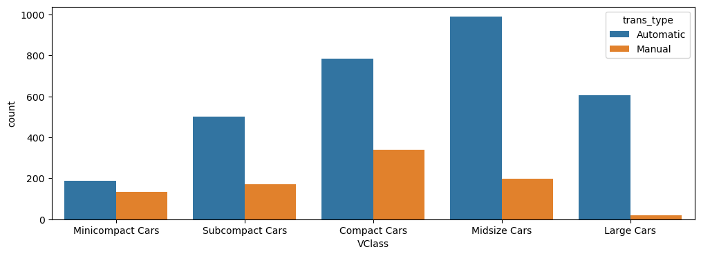

```python
sb.countplot(data = fuel_econ, x = 'VClass', hue = 'trans_type')
```

## Alternative Approach

Plot a Heat Map between two qualitative variables One alternative way of depicting the relationship between two categorical variables is through a heat map. Heat maps were introduced earlier as the 2-D version of a histogram; here, we're using them as the 2-D version of a bar chart. The seaborn function heatmap()(opens in a new tab) is at home with this type of heat map implementation, but the input arguments are unlike most of the visualization functions that have been introduced in this course. Instead of providing the original dataframe, we need to summarize the counts into a matrix that will then be plotted.

```python
# Get the data into desirable format - a DataFrame
# Use group_by() and size() to get the number of cars and each combination of the two variable levels as a pandas Series
ct_counts = fuel_econ.groupby(['VClass', 'trans_type']).size()
```

```python
# Use Series.reset_index() to convert a series into a dataframe object
ct_counts = ct_counts.reset_index(name='count')
```

```python
# Use DataFrame.pivot() to rearrange the data, to have vehicle class on rows
ct_counts = ct_counts.pivot(index = 'VClass', columns = 'trans_type', values = 'count')
```

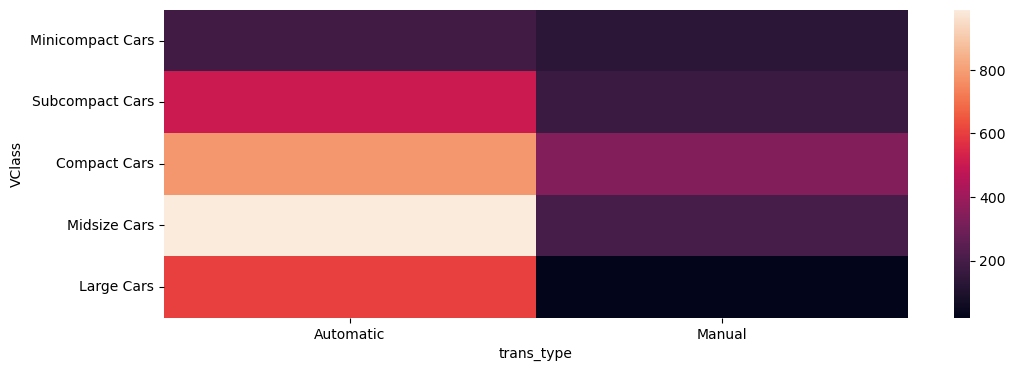

```python
sb.heatmap(ct_counts)
```

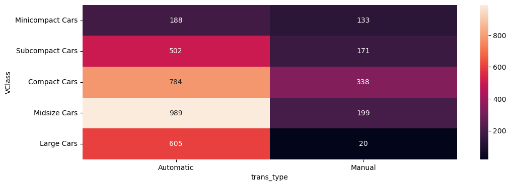

```python
sb.heatmap(ct_counts, annot = True, fmt = 'd')
```

```python
fuel_econ.columns
```

```
Index(['id', 'make', 'model', 'year', 'VClass', 'drive', 'trans', 'fuelType',
       'cylinders', 'displ', 'pv2', 'pv4', 'city', 'UCity', 'highway',
       'UHighway', 'comb', 'co2', 'feScore', 'ghgScore'],
      dtype='object')
```

```python
fuel_econ.rename(columns={'id':'x',
                         "year":'hh',
                         'trans':'t'},inplace=True)
```

```python
fuel_econ
```

|  | x | make | model | hh | VClass | drive | t | fuelType | cylinders | displ | pv2 | pv4 | city | UCity | highway | UHighway | comb | co2 | feScore | ghgScore |
| --- | --- | --- | --- | --- | --- | --- | --- | --- | --- | --- | --- | --- | --- | --- | --- | --- | --- | --- | --- | --- |
| 0 | 32204 | Nissan | GT-R | 2013 | Subcompact Cars | All-Wheel Drive | Automatic (AM6) | Premium Gasoline | 6 | 3.8 | 79 | 0 | 16.4596 | 20.2988 | 22.5568 | 30.1798 | 18.7389 | 471 | 4 | 4 |
| 1 | 32205 | Volkswagen | CC | 2013 | Compact Cars | Front-Wheel Drive | Automatic (AM-S6) | Premium Gasoline | 4 | 2.0 | 94 | 0 | 21.8706 | 26.9770 | 31.0367 | 42.4936 | 25.2227 | 349 | 6 | 6 |
| 2 | 32206 | Volkswagen | CC | 2013 | Compact Cars | Front-Wheel Drive | Automatic (S6) | Premium Gasoline | 6 | 3.6 | 94 | 0 | 17.4935 | 21.2000 | 26.5716 | 35.1000 | 20.6716 | 429 | 5 | 5 |
| 3 | 32207 | Volkswagen | CC 4motion | 2013 | Compact Cars | All-Wheel Drive | Automatic (S6) | Premium Gasoline | 6 | 3.6 | 94 | 0 | 16.9415 | 20.5000 | 25.2190 | 33.5000 | 19.8774 | 446 | 5 | 5 |
| 4 | 32208 | Chevrolet | Malibu eAssist | 2013 | Midsize Cars | Front-Wheel Drive | Automatic (S6) | Regular Gasoline | 4 | 2.4 | 0 | 95 | 24.7726 | 31.9796 | 35.5340 | 51.8816 | 28.6813 | 310 | 8 | 8 |
| ... | ... | ... | ... | ... | ... | ... | ... | ... | ... | ... | ... | ... | ... | ... | ... | ... | ... | ... | ... | ... |
| 3924 | 39882 | Toyota | Prius Prime | 2018 | Midsize Cars | Front-Wheel Drive | Automatic (variable gear ratios) | Regular Gasoline | 4 | 1.8 | 0 | 0 | 55.2206 | 78.8197 | 53.0000 | 73.6525 | 54.4329 | 78 | 10 | 10 |
| 3925 | 39898 | Hyundai | Sonata Hybrid | 2018 | Midsize Cars | Front-Wheel Drive | Automatic (AM6) | Regular Gasoline | 4 | 2.0 | 0 | 106 | 39.0000 | 55.9000 | 44.3066 | 64.0000 | 41.0000 | 217 | 9 | 9 |
| 3926 | 39899 | Hyundai | Sonata Hybrid SE | 2018 | Midsize Cars | Front-Wheel Drive | Automatic (AM6) | Regular Gasoline | 4 | 2.0 | 0 | 106 | 40.0000 | 56.0000 | 46.0000 | 64.0000 | 42.0000 | 212 | 9 | 9 |
| 3927 | 39900 | Lexus | LS 500 | 2018 | Midsize Cars | Rear-Wheel Drive | Automatic (S10) | Premium Gasoline | 6 | 3.4 | 99 | 0 | 19.2200 | 24.2000 | 30.2863 | 43.4000 | 23.0021 | 387 | 5 | 5 |
| 3928 | 39901 | Lexus | LS 500 AWD | 2018 | Midsize Cars | All-Wheel Drive | Automatic (S10) | Premium Gasoline | 6 | 3.4 | 99 | 0 | 18.0431 | 22.6000 | 27.0000 | 39.3000 | 21.3945 | 417 | 4 | 4 |

3929 rows × 20 columns

```python
fuel_econ['make'].replace(to_replace="hhhh",value=1,inplace=True)
```

```python
fuel_econ.to_csv("new.csv",index=False)
```

```python
df=pd.read_csv("new.csv")
df.head()
```

|  | x | make | model | hh | VClass | drive | t | fuelType | cylinders | displ | pv2 | pv4 | city | UCity | highway | UHighway | comb | co2 | feScore | ghgScore |
| --- | --- | --- | --- | --- | --- | --- | --- | --- | --- | --- | --- | --- | --- | --- | --- | --- | --- | --- | --- | --- |
| 0 | 32204 | Nissan | GT-R | 2013 | Subcompact Cars | All-Wheel Drive | Automatic (AM6) | Premium Gasoline | 6 | 3.8 | 79 | 0 | 16.4596 | 20.2988 | 22.5568 | 30.1798 | 18.7389 | 471 | 4 | 4 |
| 1 | 32205 | Volkswagen | CC | 2013 | Compact Cars | Front-Wheel Drive | Automatic (AM-S6) | Premium Gasoline | 4 | 2.0 | 94 | 0 | 21.8706 | 26.9770 | 31.0367 | 42.4936 | 25.2227 | 349 | 6 | 6 |
| 2 | 32206 | Volkswagen | CC | 2013 | Compact Cars | Front-Wheel Drive | Automatic (S6) | Premium Gasoline | 6 | 3.6 | 94 | 0 | 17.4935 | 21.2000 | 26.5716 | 35.1000 | 20.6716 | 429 | 5 | 5 |
| 3 | 32207 | Volkswagen | CC 4motion | 2013 | Compact Cars | All-Wheel Drive | Automatic (S6) | Premium Gasoline | 6 | 3.6 | 94 | 0 | 16.9415 | 20.5000 | 25.2190 | 33.5000 | 19.8774 | 446 | 5 | 5 |
| 4 | 32208 | Chevrolet | Malibu eAssist | 2013 | Midsize Cars | Front-Wheel Drive | Automatic (S6) | Regular Gasoline | 4 | 2.4 | 0 | 95 | 24.7726 | 31.9796 | 35.5340 | 51.8816 | 28.6813 | 310 | 8 | 8 |